# covariate_data

Jeffrey Minucci

# Introduction

Covariate analysis for 2015 rare data collected by Ohio State.

Goals:

1. Determine whether neonic concentrations in field pollen or dead bee samples were related to the percent coverage of corn planted nearby.
2. Determine whether neonic concentrations in field pollen or dead bee samples were linked with greater bee mortality.

# Distribution

The git repo holding this code is available at: https://github.com/puruckertom/rare_pollen

# Computational environment

Version and installed libraries.

```r
verbose_output = TRUE

if(verbose_output){
  print(Sys.info()[4])
  R.Version()$version.string
}
```

```
##          nodename
## "DZ2626UJMINUCCI"
```

```
## [1] "R version 3.4.3 (2017-11-30)"
```

```r
#check to see if needed packages are installed
list.of.packages <- c("ggplot2", "dplyr")
new.packages <- list.of.packages[!(list.of.packages %in% installed.packages()[,"Package"])]
if(length(new.packages)) install.packages(new.packages)
#load relevant packages
library(MASS)
library(dplyr, warn.conflicts = FALSE)
library(ggplot2)
library(reshape2)

if(verbose_output){
  print("list of loaded packages: ")
  print((.packages()))
}
```

```
## [1] "list of loaded packages: "
##  [1] "reshape2"  "ggplot2"   "dplyr"     "MASS"      "stats"
##  [6] "graphics"  "grDevices" "utils"     "datasets"  "methods"
## [11] "base"
```

# Analytical data

##### Original file with observational data:

https://github.com/puruckertom/rare_pollen/blob/master/data_in/rare_data_osu_2015.csv

```r
##################
#the data sets
##################
#import raw data - everything
file.exists(paste(osu_data,"CDRC_2017EPA_FP_DBT.csv",sep=""))
```

```
## [1] TRUE
```

```r
osu_covariate <- read.table(paste(osu_data,"CDRC_2017EPA_FP_DBT.csv",sep=""), header = TRUE, sep = ",",strip.white=T,na.strings="")
```

##### Cleaning the data:

```r
osu_covariate <- osu_covariate[,1:23]
colnames(osu_covariate)[c(4,6)] <- c("planting","per_corn")
osu_covariate$planting<- factor(osu_covariate$planting,labels=c("no","yes"))
neonics_cols <- which(grepl("DBT|FP",colnames(osu_covariate))& !grepl("sample_id",colnames(osu_covariate)))

#Create categorical vars which track whether any given neonic was detected
neonics_detected <- as.data.frame(lapply(osu_covariate[,neonics_cols],function(x) ifelse((grepl("<",x) | is.na(x)),0,1)))
colnames(neonics_detected) <- paste(colnames(neonics_detected),"detected",sep="_")
osu_covariate <- cbind(osu_covariate,neonics_detected)

#Create two single categorical vars which tracks whether ANY neonic was detected in dead bees or pollen
osu_covariate$DBT_any_detected <- ifelse(rowSums(neonics_detected[,grepl("DBT",colnames(neonics_detected))]) > 0,1,0)
osu_covariate$FP_any_detected <- ifelse(rowSums(neonics_detected[,grepl("FP",colnames(neonics_detected))]) > 0,1,0)


#convert neonic concs to numeric
osu_covariate[,neonics_cols] <- as.numeric(gsub("< ","",as.matrix(osu_covariate[,neonics_cols])))

#create variables for total neonic loads
osu_covariate$DBT_total_neonic <- rowSums(osu_covariate[,grepl("DBT",colnames(osu_covariate))& !grepl("sample_id|detected",colnames(osu_covariate))])

osu_covariate$FP_total_neonic <- rowSums(osu_covariate[,grepl("FP",colnames(osu_covariate))& !grepl("sample_id|detected",colnames(osu_covariate))])

neonics_cols <- c(neonics_cols,which(colnames(osu_covariate) %in% c("DBT_total_neonic","FP_total_neonic")))

#write.csv(osu_covariate,"data_in/CDRC_2017EPA_FP_DBT_clean.csv",row.names=FALSE) #output a csv for the cleaned data

#str(osu_covariate) #display summary of cleaned dataframe
```

# Exploring the data

#### Let’s make a quick scan for correlations in the data….

##### Any correlations between the percent corn nearby and the neonic concentrations?

```r
for(i in 1:length(neonics_cols)){
  cor <- cor.test(osu_covariate$per_corn, osu_covariate[,neonics_cols[i]])
  cat("\n",paste("Correlation between % corn and ",
                 ifelse(substr(colnames(osu_covariate[,neonics_cols])[i],1,2)=="FP",
                        paste("field pollen",substr(colnames(osu_covariate[,neonics_cols])[i],4,20)),
                        paste("dead bees",substr(colnames(osu_covariate[,neonics_cols])[i],5,20))),":",sep=""),
      paste("Pearson's correlation: ",round(cor$estimate,2),', p-value: ',
            ifelse(cor$p.value < 0.001,"<0.001",round(cor$p.value,3)),ifelse(cor$p.value < 0.05,"***",""),sep=""),sep="\n")
}
```

```
##
##
## Correlation between % corn and dead bees dinotefuran:
## Pearson's correlation: -0.09, p-value: 0.356
##
##
## Correlation between % corn and dead bees nitenpyram:
## Pearson's correlation: -0.04, p-value: 0.707
##
##
## Correlation between % corn and dead bees thiamethoxam:
## Pearson's correlation: -0.01, p-value: 0.887
##
##
## Correlation between % corn and dead bees clothianidin:
## Pearson's correlation: 0.02, p-value: 0.811
##
##
## Correlation between % corn and dead bees imidacloprid:
## Pearson's correlation: 0.1, p-value: 0.299
##
##
## Correlation between % corn and dead bees acetamiprid:
## Pearson's correlation: -0.01, p-value: 0.951
##
##
## Correlation between % corn and dead bees thiacloprid:
## Pearson's correlation: -0.17, p-value: 0.092
##
##
## Correlation between % corn and field pollen dinotefuran:
## Pearson's correlation: -0.16, p-value: 0.121
##
##
## Correlation between % corn and field pollen nitenpyram:
## Pearson's correlation: 0.07, p-value: 0.494
##
##
## Correlation between % corn and field pollen thiamethoxam:
## Pearson's correlation: 0.2, p-value: 0.055
```

[output cut: 9 more lines]

```
##
## Correlation between % corn and field pollen acetamiprid:
## Pearson's correlation: -0.15, p-value: 0.158
##
##
## Correlation between % corn and field pollen thiacloprid:
## Pearson's correlation: -0.06, p-value: 0.57
##
##
## Correlation between % corn and dead bees total_neonic:
## Pearson's correlation: 0.01, p-value: 0.91
##
##
## Correlation between % corn and field pollen total_neonic:
## Pearson's correlation: 0.2, p-value: 0.057
```

**It looks like there are near-significant postive correlations between *% corn* and two neonics, *thiamethoxam* and *clothianidin*, in pollen as well as *total neonic load* in pollen.**

##### What if we just look at this relationship during defined corn planting periods?

```r
for(i in 1:length(neonics_cols)){
  cor <- cor.test(subset(osu_covariate,planting=="yes")$per_corn, subset(osu_covariate,planting=="yes")[,neonics_cols[i]])
  cat("\n",paste("Correlation between % corn and ",
                 ifelse(substr(colnames(osu_covariate[,neonics_cols])[i],1,2)=="FP",
                        paste("field pollen",substr(colnames(osu_covariate[,neonics_cols])[i],4,20)),
                        paste("dead bees",substr(colnames(osu_covariate[,neonics_cols])[i],5,20))),":",sep=""),
      paste("Pearson's correlation: ",round(cor$estimate,2),', p-value: ',
            ifelse(cor$p.value < 0.001,"<0.001",round(cor$p.value,3)),ifelse(cor$p.value < 0.05,"***",""),sep=""),sep="\n")
}
```

```
##
##
## Correlation between % corn and dead bees dinotefuran:
## Pearson's correlation: 0.08, p-value: 0.672
##
##
## Correlation between % corn and dead bees nitenpyram:
## Pearson's correlation: 0.11, p-value: 0.567
##
##
## Correlation between % corn and dead bees thiamethoxam:
## Pearson's correlation: 0.21, p-value: 0.266
##
##
## Correlation between % corn and dead bees clothianidin:
## Pearson's correlation: -0.04, p-value: 0.821
##
##
## Correlation between % corn and dead bees imidacloprid:
## Pearson's correlation: NA, p-value: NANA
##
##
## Correlation between % corn and dead bees acetamiprid:
## Pearson's correlation: 0.27, p-value: 0.152
##
##
## Correlation between % corn and dead bees thiacloprid:
## Pearson's correlation: -0.01, p-value: 0.978
##
##
## Correlation between % corn and field pollen dinotefuran:
## Pearson's correlation: -0.02, p-value: 0.904
##
##
## Correlation between % corn and field pollen nitenpyram:
## Pearson's correlation: -0.11, p-value: 0.554
##
##
## Correlation between % corn and field pollen thiamethoxam:
## Pearson's correlation: 0.4, p-value: 0.028***
```

[output cut: 9 more lines]

```
##
## Correlation between % corn and field pollen acetamiprid:
## Pearson's correlation: -0.19, p-value: 0.307
##
##
## Correlation between % corn and field pollen thiacloprid:
## Pearson's correlation: -0.19, p-value: 0.311
##
##
## Correlation between % corn and dead bees total_neonic:
## Pearson's correlation: 0.24, p-value: 0.205
##
##
## Correlation between % corn and field pollen total_neonic:
## Pearson's correlation: 0.39, p-value: 0.032***
```

**During planting periods, there are significant correlations between *thiamethoxam* and *clothianidin* in pollen, as well as *total neonic pollen load.* We may want to focus some analyses on these two chemicals.**

##### What about correlations between bee mortality and the neonic concentrations?

```r
for(i in 1:length(neonics_cols)){
  cor <- cor.test(osu_covariate$mortality, osu_covariate[,neonics_cols[i]])
  cat("\n",paste("Correlation between mortality and ",
                 ifelse(substr(colnames(osu_covariate[,neonics_cols])[i],1,2)=="FP",
                        paste("field pollen",substr(colnames(osu_covariate[,neonics_cols])[i],4,20)),
                        paste("dead bees",substr(colnames(osu_covariate[,neonics_cols])[i],5,20))), ":",sep=""),
      paste("Pearson's correlation: ",round(cor$estimate,2),', p-value: ',
            ifelse(cor$p.value < 0.001,"<0.001",round(cor$p.value,3)),ifelse(cor$p.value < 0.05,"***",""),sep=""),sep="\n")
}
```

```
##
##
## Correlation between mortality and dead bees dinotefuran:
## Pearson's correlation: -0.05, p-value: 0.612
##
##
## Correlation between mortality and dead bees nitenpyram:
## Pearson's correlation: -0.02, p-value: 0.834
##
##
## Correlation between mortality and dead bees thiamethoxam:
## Pearson's correlation: 0.07, p-value: 0.473
##
##
## Correlation between mortality and dead bees clothianidin:
## Pearson's correlation: -0.13, p-value: 0.19
##
##
## Correlation between mortality and dead bees imidacloprid:
## Pearson's correlation: -0.02, p-value: 0.844
##
##
## Correlation between mortality and dead bees acetamiprid:
## Pearson's correlation: -0.06, p-value: 0.548
##
##
## Correlation between mortality and dead bees thiacloprid:
## Pearson's correlation: -0.09, p-value: 0.354
##
##
## Correlation between mortality and field pollen dinotefuran:
## Pearson's correlation: 0.02, p-value: 0.825
##
##
## Correlation between mortality and field pollen nitenpyram:
## Pearson's correlation: 0.09, p-value: 0.399
##
##
## Correlation between mortality and field pollen thiamethoxam:
## Pearson's correlation: 0.51, p-value: <0.001***
```

[output cut: 9 more lines]

```
##
## Correlation between mortality and field pollen acetamiprid:
## Pearson's correlation: 0.04, p-value: 0.684
##
##
## Correlation between mortality and field pollen thiacloprid:
## Pearson's correlation: -0.13, p-value: 0.208
##
##
## Correlation between mortality and dead bees total_neonic:
## Pearson's correlation: -0.13, p-value: 0.204
##
##
## Correlation between mortality and field pollen total_neonic:
## Pearson's correlation: 0.56, p-value: <0.001***
```

**There are strong positive correlations between mortality and the same two neonics, *thiamethoxam* and *clothianidin*, for field pollen samples. There is also a significant positive correlation for *total neonic load* in pollen.**

# Regression analysis - are there higher neonic loads when there’s more corn nearby?

##### We will model *neonic concentrations* as a function of *percent corn* nearby and whether measurement occured during the *corn planting period*.

##### If we see a significant interaction between *percent corn* and *planting period*, then there is evidence that the effect of corn is different during planting periods.

##### Lets start by looking at the just two neonics that we previously identified, as well as a total pollen neonic load:

```r
interesting_neonics <- c("FP_thiamethoxam","FP_clothianidin","FP_total_neonic")

for(i in 1:length(interesting_neonics)){
  fm <- lm(as.formula(paste(interesting_neonics[i],"~ per_corn * planting",
                            sep="")),data=osu_covariate)
  cat("-------------------------------------\n\n",paste("Linear regression, ",interesting_neonics[i]," vs percent corn:",sep=""),"\n")
  print(summary(fm))
  #hist(resid(fm))
}
```

```
## -------------------------------------
##
##  Linear regression, FP_thiamethoxam vs percent corn:
##
## Call:
## lm(formula = as.formula(paste(interesting_neonics[i], "~ per_corn * planting",
##     sep = "")), data = osu_covariate)
##
## Residuals:
##     Min      1Q  Median      3Q     Max
## -12.976  -2.175  -1.189   0.984  32.119
##
## Coefficients:
##                      Estimate Std. Error t value Pr(>|t|)
## (Intercept)           2.17362    1.62008   1.342  0.18323
## per_corn              0.00682    0.05701   0.120  0.90504
## plantingyes          -1.97310    2.80607  -0.703  0.48386
## per_corn:plantingyes  0.28221    0.09874   2.858  0.00534 **
## ---
## Signif. codes:  0 '***' 0.001 '**' 0.01 '*' 0.05 '.' 0.1 ' ' 1
##
## Residual standard error: 5.886 on 86 degrees of freedom
##   (10 observations deleted due to missingness)
## Multiple R-squared:  0.2452, Adjusted R-squared:  0.2189
## F-statistic: 9.315 on 3 and 86 DF,  p-value: 2.128e-05
##
## -------------------------------------
##
##  Linear regression, FP_clothianidin vs percent corn:
##
## Call:
## lm(formula = as.formula(paste(interesting_neonics[i], "~ per_corn * planting",
##     sep = "")), data = osu_covariate)
##
## Residuals:
##     Min      1Q  Median      3Q     Max
## -27.474  -2.523  -1.850   1.165  62.183
##
## Coefficients:
##                      Estimate Std. Error t value Pr(>|t|)
```

[output cut: 22 more lines]

```
## -41.928  -7.157  -4.199   2.955  94.669
##
## Coefficients:
##                      Estimate Std. Error t value Pr(>|t|)
## (Intercept)            9.7514     4.7959   2.033   0.0451 *
## per_corn               0.0544     0.1688   0.322   0.7479
## plantingyes           -0.8539     8.3068  -0.103   0.9184
## per_corn:plantingyes   0.7433     0.2923   2.543   0.0128 *
## ---
## Signif. codes:  0 '***' 0.001 '**' 0.01 '*' 0.05 '.' 0.1 ' ' 1
##
## Residual standard error: 17.42 on 86 degrees of freedom
##   (10 observations deleted due to missingness)
## Multiple R-squared:  0.2721, Adjusted R-squared:  0.2468
## F-statistic: 10.72 on 3 and 86 DF,  p-value: 4.689e-06
```

**Summary: concentrations of these two neonics in pollen, as well as total neonic load, were increased when more corn was planted nearby, but ONLY during corn planting periods (see significant positive *percent corn by planting interaction*).**

**Note: significant relationships do not hold if we remove the site with very high neonic concentrations.**

##### Let’s graph how percent corn nearby affects field pollen concentrations of these neonics, by planting period:

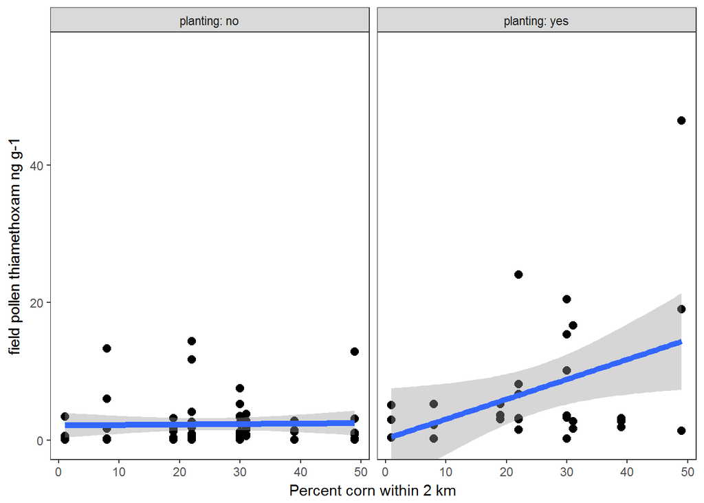

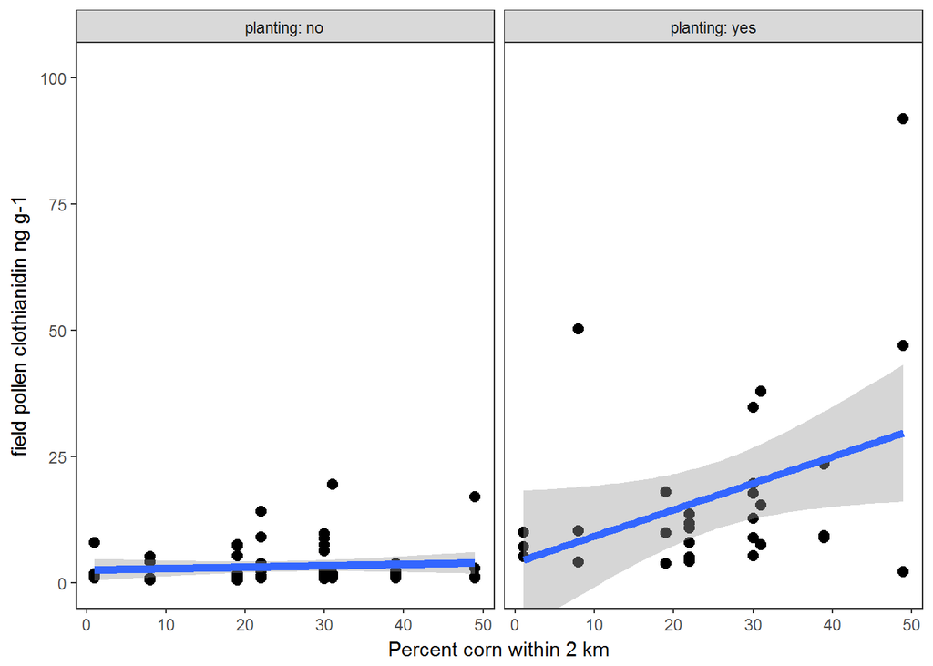

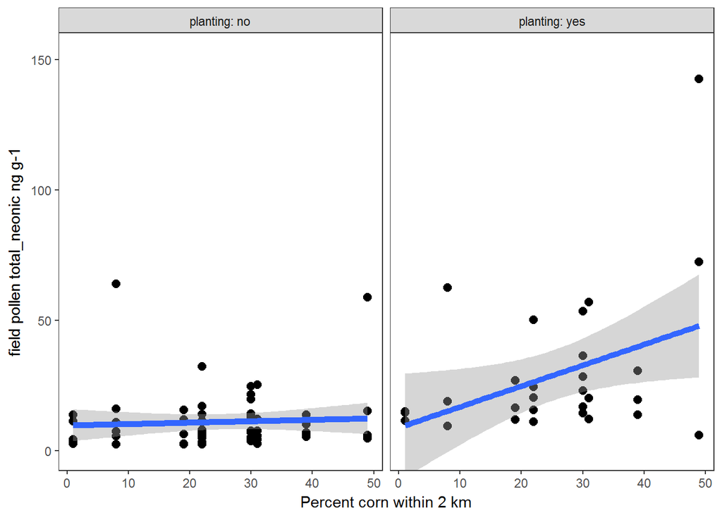

```r
for(i in 1:length(interesting_neonics)){
  g <- ggplot(osu_covariate,aes_string("per_corn",interesting_neonics[i]))+geom_point(na.rm=T,size=2.5)+
    geom_smooth(method="lm",formula=y~x,na.rm=T,size=2)+facet_wrap(~planting,nrow=1,labeller=label_both)+theme_bw()+
    theme(panel.grid.major=element_blank(),panel.grid.minor=element_blank())+
    coord_cartesian(ylim=c(0,max(osu_covariate[,interesting_neonics[i]],na.rm=T)+10)) +
    labs(x="Percent corn within 2 km",y=paste(ifelse(substr(interesting_neonics[i],1,2)=="FP",
                        paste("field pollen",substr(interesting_neonics[i],4,20)),
                        paste("dead bees",substr(interesting_neonics[i],5,20))),"ng g-1"))
  print(g)
}
```

##### Let’s do a check to see if there are similar relationships for any other neonics (in pollen or dead bees)

Note: output not shown

```r
neonics_to_eval <- colnames(osu_covariate)[which(grepl("FP|DBT",colnames(osu_covariate))& !grepl("FP_clothianidin|FP_thiamethoxam|FP_total_|detected|sample_id",colnames(osu_covariate)))]

for(i in 1:length(neonics_to_eval)){
  fm <- lm(as.formula(paste(neonics_to_eval[i],"~ per_corn * planting",
                            sep="")),data=osu_covariate)
  cat("\n",paste("Linear regression, ",neonics_to_eval[i]," vs percent corn:",sep=""),"\n")
  print(summary(fm))
  #hist(resid(fm))
}
```

**Summary: not seeing any other significant relationships.**

# Regression analysis - is mortality higher when neonic loads are higher?

```
## -------------------------------------
##
##  Linear regression, FP_thiamethoxam vs mortality:
##
## Call:
## lm(formula = as.formula(paste("mortality ~ ", interesting_neonics[i],
##     sep = "")), data = osu_covariate)
##
## Residuals:
##      Min       1Q   Median       3Q      Max
## -1.44866 -0.45229 -0.08819  0.21550  2.04028
##
## Coefficients:
##                 Estimate Std. Error t value Pr(>|t|)
## (Intercept)     -0.07962    0.08554  -0.931    0.355
## FP_thiamethoxam  0.06130    0.01102   5.562 2.83e-07 ***
## ---
## Signif. codes:  0 '***' 0.001 '**' 0.01 '*' 0.05 '.' 0.1 ' ' 1
##
## Residual standard error: 0.6924 on 88 degrees of freedom
##   (10 observations deleted due to missingness)
## Multiple R-squared:  0.2601, Adjusted R-squared:  0.2517
## F-statistic: 30.94 on 1 and 88 DF,  p-value: 2.828e-07
```

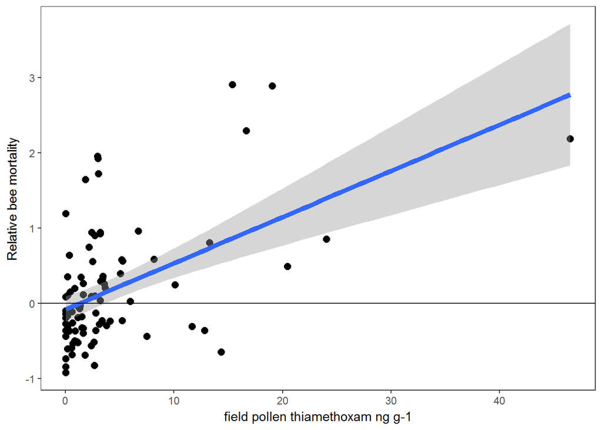

```
## -------------------------------------
##
##  Linear regression, FP_clothianidin vs mortality:
##
## Call:
## lm(formula = as.formula(paste("mortality ~ ", interesting_neonics[i],
##     sep = "")), data = osu_covariate)
##
## Residuals:
##     Min      1Q  Median      3Q     Max
## -1.4099 -0.3974 -0.1310  0.3218  1.8108
##
## Coefficients:
##                  Estimate Std. Error t value Pr(>|t|)
## (Intercept)     -0.129200   0.078795  -1.640    0.105
## FP_clothianidin  0.037579   0.005194   7.234 1.65e-10 ***
## ---
## Signif. codes:  0 '***' 0.001 '**' 0.01 '*' 0.05 '.' 0.1 ' ' 1
##
## Residual standard error: 0.6374 on 88 degrees of freedom
##   (10 observations deleted due to missingness)
## Multiple R-squared:  0.3729, Adjusted R-squared:  0.3658
## F-statistic: 52.34 on 1 and 88 DF,  p-value: 1.646e-10
```

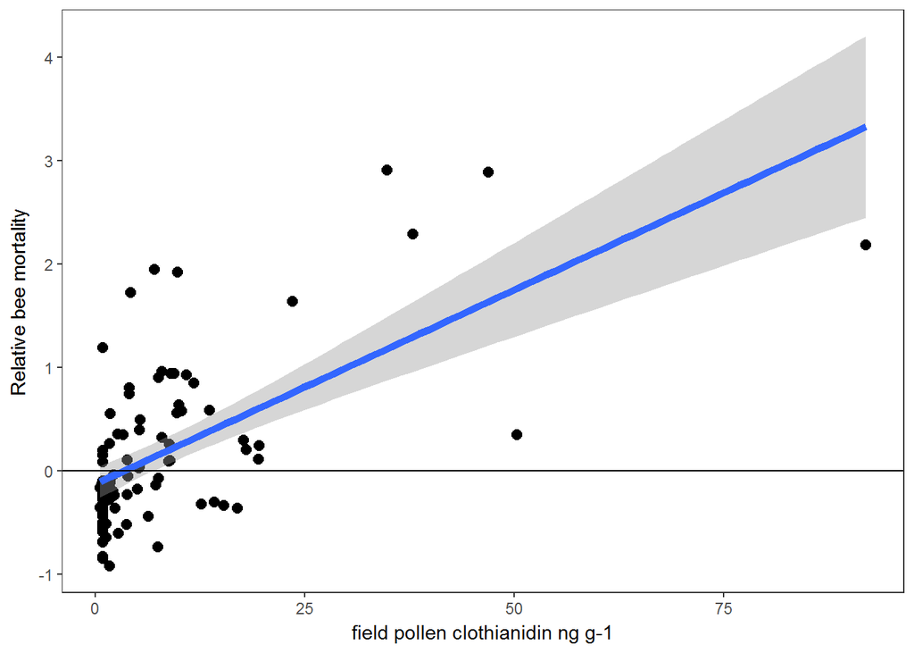

```
## -------------------------------------
##
##  Linear regression, FP_total_neonic vs mortality:
##
## Call:
## lm(formula = as.formula(paste("mortality ~ ", interesting_neonics[i],
##     sep = "")), data = osu_covariate)
##
## Residuals:
##     Min      1Q  Median      3Q     Max
## -1.4582 -0.4308 -0.1502  0.2786  1.9264
##
## Coefficients:
##                  Estimate Std. Error t value Pr(>|t|)
## (Intercept)     -0.209974   0.092695  -2.265    0.026 *
## FP_total_neonic  0.022198   0.003531   6.287 1.21e-08 ***
## ---
## Signif. codes:  0 '***' 0.001 '**' 0.01 '*' 0.05 '.' 0.1 ' ' 1
##
## Residual standard error: 0.6687 on 88 degrees of freedom
##   (10 observations deleted due to missingness)
## Multiple R-squared:   0.31,  Adjusted R-squared:  0.3021
## F-statistic: 39.53 on 1 and 88 DF,  p-value: 1.21e-08
```

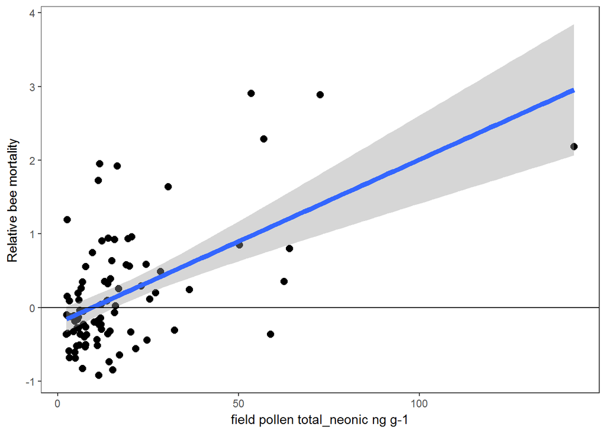

```r
for(i in 1:length(interesting_neonics)){
  fm <- lm(as.formula(paste("mortality ~ ",interesting_neonics[i],
                            sep="")),data=osu_covariate)
  cat("-------------------------------------\n\n",
      paste("Linear regression, ",interesting_neonics[i]," vs mortality:",sep=""),"\n")
  print(summary(fm))
  #hist(resid(fm))
  g <- ggplot(osu_covariate,aes_string(interesting_neonics[i],"mortality"))+geom_point(na.rm=T,size=2.5)+
    geom_smooth(method="lm",formula=y~x,na.rm=T,size=2)+theme_bw()+
    theme(panel.grid.major=element_blank(),panel.grid.minor=element_blank()) +
    labs(x=paste(ifelse(substr(interesting_neonics[i],1,2)=="FP",
                        paste("field pollen",substr(interesting_neonics[i],4,20)),
                        paste("dead bees",substr(interesting_neonics[i],5,20))),"ng g-1"),
         y="Relative bee mortality")+geom_hline(yintercept=0)
  print(g)
}
```

**Summary: As concentrations of *thiamethoxam*, *clothianidin* and *total neonics* in field pollen increased, there was greater bee mortality.**

**Note: these relationships hold even if you remove the site with very high neonic concentrations.**

# Summary of initial findings

1. During corn planting periods only… there were greater concentrations of two neonic insecticides, **thiamethoxam** and **clothianidin**, and greater **total neonic concentrations** in field pollen when there was more corn planted nearby (within 2 km). The corn effect *does not* hold if we remove one observation that had very high **clothianidin** and **thiamethoxam** levels.
2. Greater concentrations of these same neonics, as well as total neonic load, were associated with increased bee mortality. This effect holds even with the very high observation removed.
3. No significant relationships were found for other neonics measured in field pollen, or for any measurements from dead bees.